# Regression

Ben Whalley

October 2021

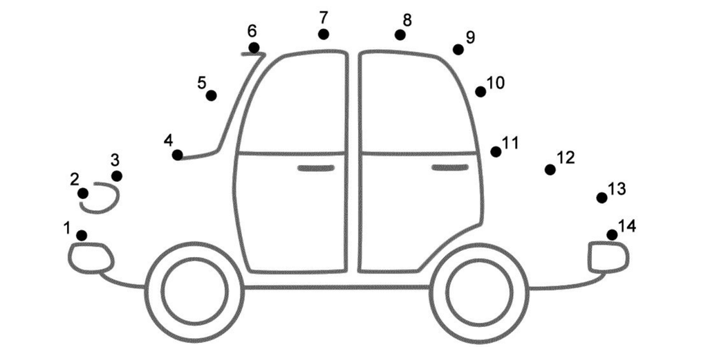

# In brief

> Linear regression is a fancy term for drawing the ‘best-fitting’ line through a scatter plot of two variables, and summarising how well the line describes the data.

> When doing regression in R, the relationship between an *outcome* and one or more *predictors* is described using a *formula*. When a model is ‘*fitted*’ to a sample it becomes tool to make *predictions* for future samples. It also allows us to quantify our *uncertainty* about those predictions.

> *Coefficients* are numbers telling us how strong the relationships between predictors and outcomes are. But the meaning of coefficients depend entirely on the *design* of our study, and the *assumptions* we are prepared to make. Causal diagrams (as you drew in the first session) can help us decide how to interpret our results.

# Before you start

- Make a new Rmd file to save your work in this session. Call it `regression.rmd`. Make sure you save it in the same directory (folder) as your data handling file.

# By eye

We want to fit lines though our data because we can use them to make *predictions for new data* (i.e. future students).

In the workshop we fitted different shape *lines* (straight, curved) to different *samples* from the sample *population*.

We found that the straight line was the *worst fit* for the initial sample we used to draw the line, as compared with a curved line.

However, when we used the same line to predict observations in a *new sample* then the straight line was better than the curved.

The principle here is that the curved lines we drew *over-fitted* the data. This is why we want to use simple models (like straight lines) as much as we possibly can.

**Only do this *after* the workshop; use the time in class to complete the exercises below.**

Once you have done the class exercise read this more detailed explanation of what is going on.

# First regression model

In this exercise we will use an example dataset which contains 5 variables from a questionnaire about study habits.

The dataset is called `studyhabits` and is in the `psydata` package.

`studyhabits` also contains a test score (`grade`) and some demographic variables on participants:

```r
studyhabits %>% glimpse
```

```
Rows: 300
Columns: 9
$ work_consistently <dbl> 4, 3, 2, 4, 3, 3, 3, 3, 4, 3, 3, 3, 4, 3, 5, 3, 4, 3, 3, 2, 3, 3, 3, 4, 2, 4, 4, 3, 3, 5, 3…
$ revision_before   <dbl> 3, 4, 4, 3, 4, 4, 5, 3, 4, 4, 4, 4, 3, 3, 2, 3, 4, 4, 4, 2, 3, 3, 4, 4, 5, 4, 3, 5, 3, 3, 2…
$ focus_deadline    <dbl> 5, 3, 3, 3, 3, 2, 3, 2, 3, 3, 3, 4, 3, 3, 3, 3, 2, 4, 4, 2, 3, 3, 3, 3, 4, 3, 2, 3, 3, 4, 2…
$ progress_everyday <dbl> 4, 2, 2, 5, 2, 3, 3, 2, 3, 3, 2, 3, 4, 2, 2, 2, 3, 2, 3, 2, 3, 4, 4, 2, 3, 4, 2, 4, 2, 3, 2…
$ work_hours        <dbl> 26, 26, 16, 33, 25, 20, 32, 31, 22, 33, 22, 28, 29, 26, 18, 26, 31, 28, 23, 18, 28, 27, 23,…
$ msc_student       <lgl> TRUE, FALSE, FALSE, TRUE, TRUE, FALSE, TRUE, TRUE, FALSE, TRUE, TRUE, TRUE, TRUE, FALSE, FA…
$ female            <lgl> TRUE, TRUE, FALSE, TRUE, TRUE, TRUE, TRUE, TRUE, FALSE, TRUE, TRUE, TRUE, TRUE, TRUE, FALSE…
$ unique_id         <fct> 1122, 1123, 1124, 1125, 1126, 1127, 1128, 1129, 1130, 1131, 1132, 1133, 1134, 1135, 1136, 1…
$ grade             <dbl> 65, 57, 45, 70, 55, 50, 57, 69, 62, 63, 75, 67, 62, 63, 45, 64, 57, 68, 66, 21, 62, 64, 61,…
```

If you want to refer to it, [the questionnaire used to generate the data can be viewed here](https://forms.office.com/Pages/ResponsePage.aspx?id=6-c3VPuDGk2_07skfgYb8WEZK5mpNnxDglU_t85tVHtUME1ST0dZS0RWMlpUR1hMUFZIMDhPMkNYRi4u)

1. Load `pysdata` and `tidyverse`
2. Check the data by looking at the first 6 rows using `head` or `glimpse`

# Plotting the data first

### Density plots

Before we do any statistical analyses, we should first plot the data.

For example, a density plot or histogram is good for showing the distribution of test scores.

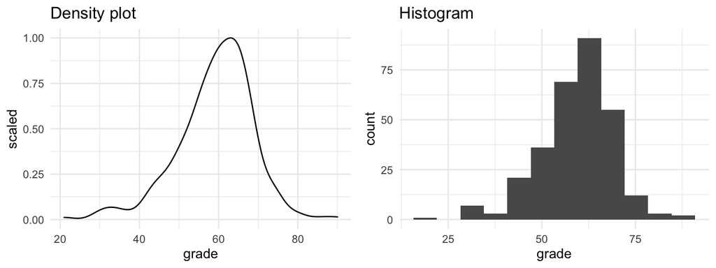

Using the `studyhabits` data in `psydata`:

- Reproduce the density plot or histogram from above.
- Make a second plot that differentiates the scores of men and women, using colour.

See making a density plot video, at the end of this worksheet

We first encountered density plots in [this worksheet](https://ajwills72.github.io/rminr/vbg_groups.html#group-density)

You can make a density plot by writing:

```r
DATA %>%
  ggplot(aes(y = COLUMN_NAME)) +
  geom_density()
```

Or a histogram by writing:

```r
DATA %>%
  ggplot(aes(y = COLUMN_NAME)) +
  geom_histogram()
```

If you want to be fancy you can write: `+ geom_density(aes(y=..scaled..))` which will set the scale on the y axis to be from 0 to 1 — that is, the value of the line on the y axis is scaled relative to the highest point.

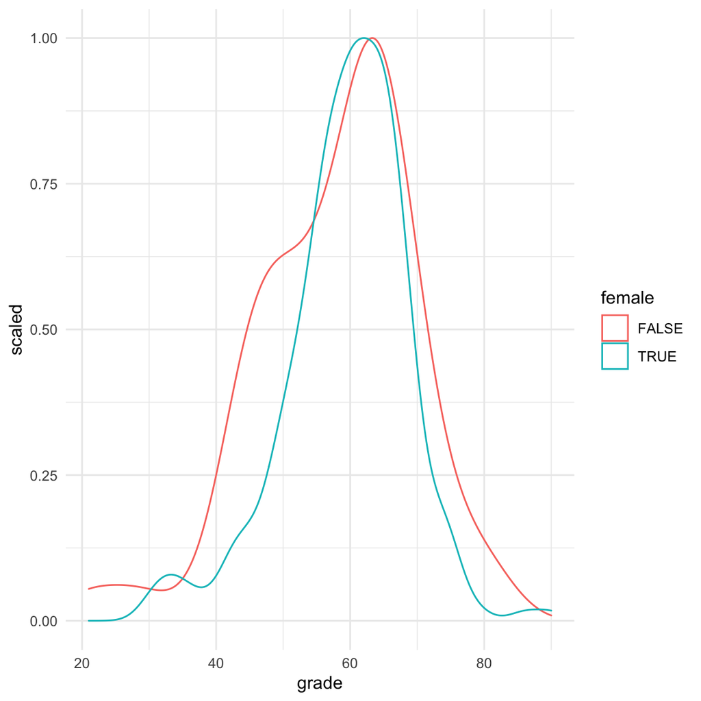

```r
studyhabits %>%
  ggplot(aes(grade, color=female)) +
    geom_density(aes(y=..scaled..))
```

- Describe in words the distribution of the `grade` variable in this dataset. You can use `summarize()` to calculate extra statistics like the `mean`, `median` or `sd` to add to the text.

This is good, because the variable we use as the *outcome* in regression should be continuous and, although not *strictly* required, it’s often helpful for it to be normally distributed.

## Scatter plots

We can also use a scatter plot to show the relationship between MCG `grade` and responses to one of the questions:

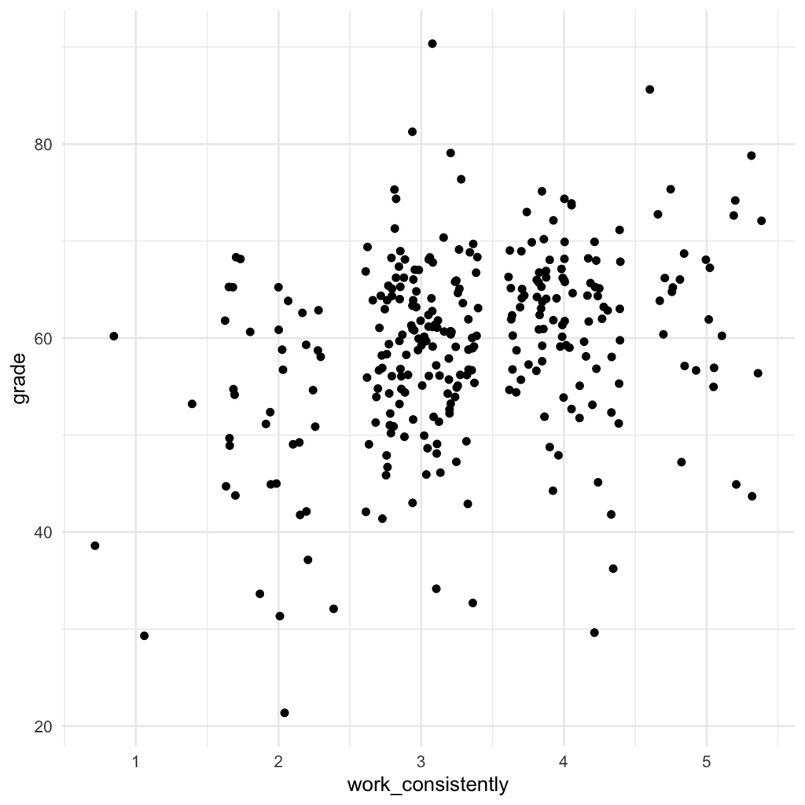

```r
studyhabits %>%
  ggplot(aes(work_consistently, grade)) +
    geom_jitter()
```

> This plot uses `geom_jitter()` rather than `geom_point()` to add noise to the data, and so reveal the pattern of responses more clearly.

Using the `studyhabits` data in `psydata`:

1. Make a scatter plot with `progress_everyday` on the x axis, and `grade` on the y axis.
2. Before we start using R to fit lines for us, agree as a group or with a partner:
   - What relationship do we see between `progress_everyday` and grades?
   - Would you say this is a weak, moderate, or strong relationship?

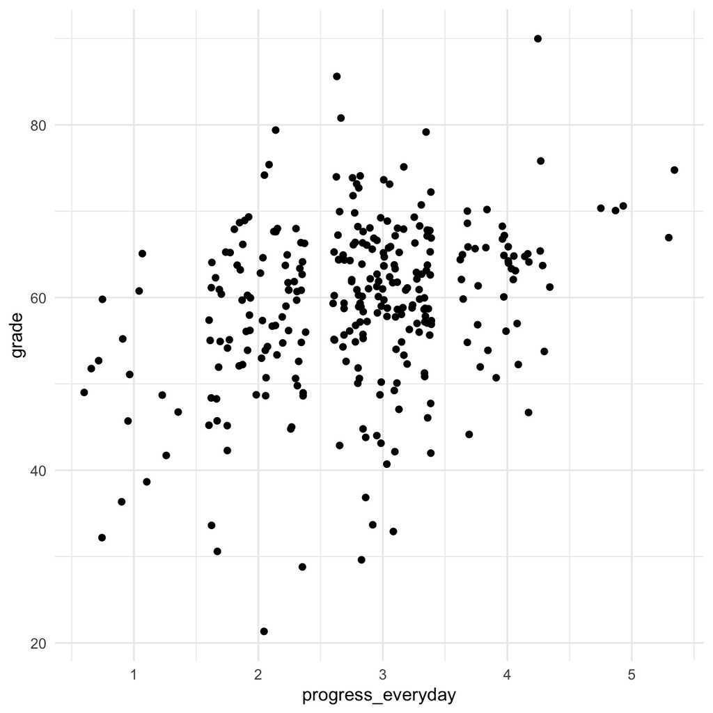

```r
studyhabits %>%
  ggplot(aes(progress_everyday, grade)) +
  geom_jitter()
```

The relationship is positive, but only moderate in strength.

The correlation is only 0.32

# Using `lm`

To get R to fit a line we use a new function called `lm`.

The letters l and m stand for **l**inear **m**odel.

There are lots of ways to use `lm`, but the easiest to *picture* is to use it as part of a `ggplot`:

[video not shown]

### Code and explanation shown in the video:

[figure not shown]

```r
studyhabits %>%
  ggplot(aes(work_hours, grade)) +
  geom_point() +
  geom_smooth(method=lm, se=F)
```

**Explanation of the code**: We used `geom_point` to create a scatterplot. Then we used a plus symbol (`+`) and added `geom_smooth(method=lm)` to add the fitted line. By default, `geom_smooth` would try to fit a curvy line through your datapoints, but adding `method=lm` makes it a straight line.

**Explanation of the resulting plot** The plot above is just like the scatter plots we drew before, but adds the blue fitted line. The blue line shows the ‘line of best fit’. This is the line that **minimises the residuals** (the gaps between the line and the points). Ignore the shaded area for now (explanation here if you are keen).

Don’t worry about trying to add the vertical and horizontal lines at zero you see in this plot. These are just shown in my version to emphasise the fact that we didn’t collect any data where `work_hours` was < 10.

You can use `geom_vline()` and `geom_hline()` to add lines at specific points on each axis. This is the exact code that made the plot above.

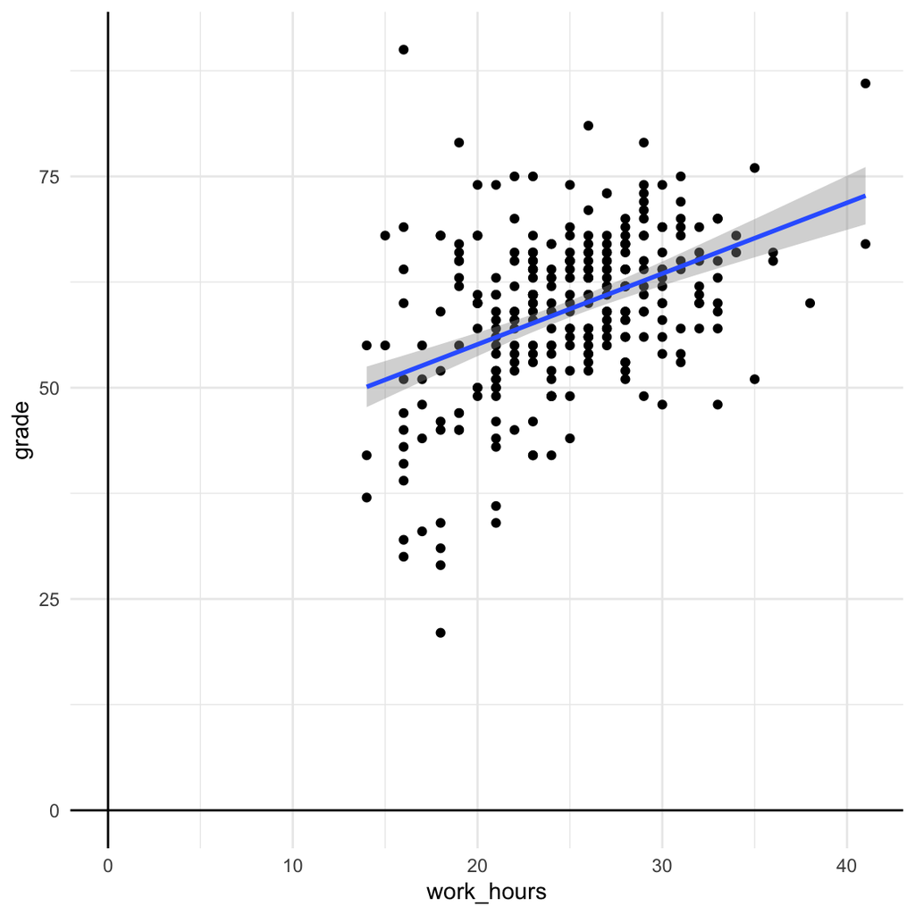

```r
studyhabits %>%
  ggplot(aes(work_hours, grade)) +
  geom_point() +
  geom_smooth(method=lm) +
  geom_vline(xintercept=0) +
  geom_hline(yintercept=0)
```

1. Using the `studyhabits` data, plot a line graph with:
- The same variables (i.e. reproduce the plot with `work_hours` and `grade`)
- Different variables (from the `studyhabits` dataset)
- Without the `method=lm` part (to see a curvy line instead of straight)
2. Now, add colour to the plot to distinguish between men and women.

Adding `colour=female` inside the part which says `aes(...)` should plot different lines for men and women. Something like this:

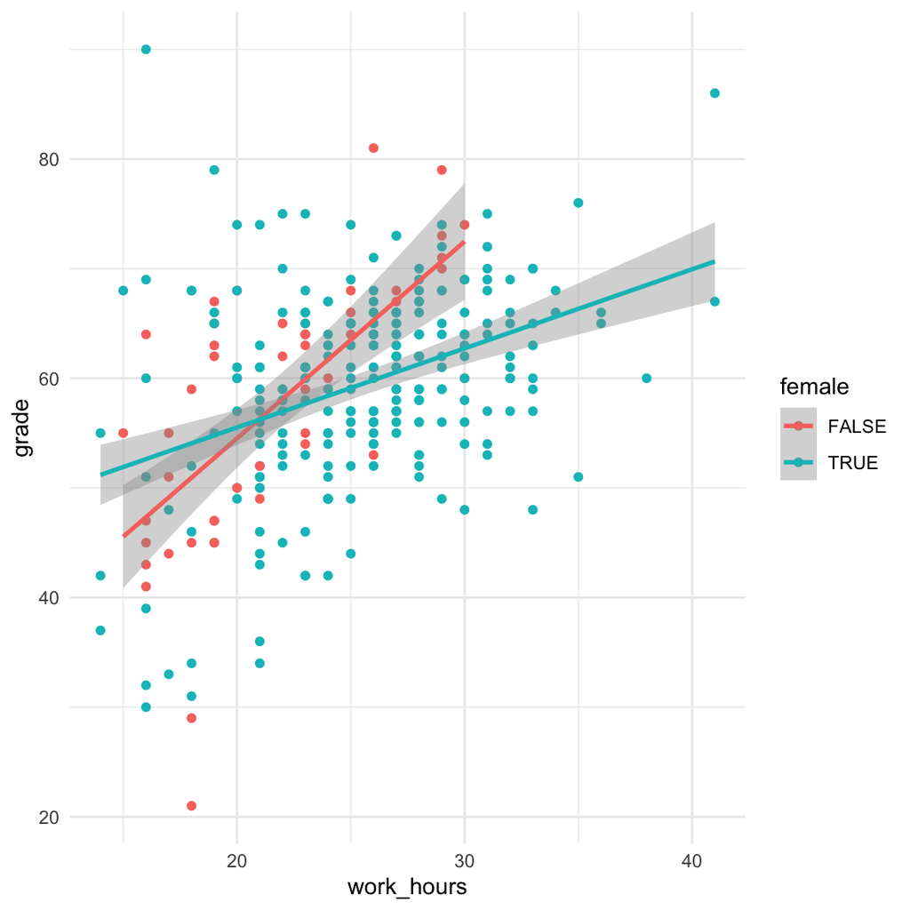

## Summary

- We can fit straight lines to data
- We use the `lm` function to do this, within `ggplot`, using `geom_smooth(method=lm)`
- We can fit multiple lines for different groups (e.g. men and women) by using the color aesthetic (in `aes()`)

# Coefficients

The plot using `lm` is helpful, because we can *see* the best-fit line.

However, we also want to have a *single number to say how steep the line is*. That is, *a number to say how closely related the variables are*.

To do this we can use the `lm` function directly:

```r
lm(grade ~ work_hours, data = studyhabits)
```

```
Call:
lm(formula = grade ~ work_hours, data = studyhabits)

Coefficients:
(Intercept)   work_hours
    38.3696       0.8377
```

**Explanation of the code** The first part tells R to use the `lm` function. The next part known as a model formula: The `~` symbol (it’s called a ‘tilde’) just means “is predicted by”, so you can read it as “grade is predicted by work hours”. Finally, we tell `lm` to use the `studyhabits` data.

**Explanation of the output**: When we use lm, the output displays:

- The ‘Call’ we made (i.e. what inputs we gave, so we can remember how we did it later on)
- The ‘coefficients’ of the model. These are the **numbers which represent the line on the graph** that we saw above.

[video not shown]

## Understanding the coefficients

In this example, we have two coefficients: the `(Intercept)` which is 38.3696 and the `work_hours` coefficient which is 0.8377.

**The best way to think about the coefficients is in relation to the plot I showed in the workshop**:

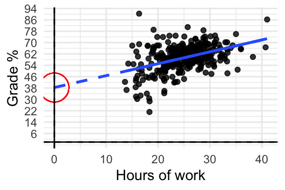

We can interpret the coefficients as follows:

- The `(Intercept)` coefficient is the height (on the y axis) where the blue dotted line crosses zero (on the x-axis).
- The `work_hours` coefficient is how **steep** the slope of the line is. Specifically, is says how many `grade` points the line will rise if we increase `work_hours` by 1.

(Watch the previous video on `lm` again for extra clarification/interpretation of the coefficients).

# Using different predictors

The `studyhabits` data has other variables we could use to predict grades.

1. Run a number of different regression models using a different predictor each time.
2. Which of the questions produces the largest slope coefficient?
3. If you could intervene to change participants, which variable would you like to alter most? (Assuming you wanted to increase test scores)

First 2 questions:

```r
# an example of another model
lm(grade ~ work_consistently, data=studyhabits)

# being an MSc student made the biggest difference!
lm(grade ~ msc_student, data=studyhabits)
```

Answering question 3 is *much* harder. In fact there is no simple right answer here.

We might say that we’d want to make all students into MSc students. After all, that was the variable with the largest coefficient, so changing that notionally has the biggest impact on grades.

But that ignores the fact that being an MSc student isn’t likely to *cause* you to have higher grades. It’s probably an example of confounding: students doing the MSc have been selected to some degree because of their ability to get higher grades on previous modules.

To make a decision between the variables we’d also have to consider the *scale* of the variables. If one of the predictors ranges between 0 and 7 (for example) whereas another ranges from 0 to 100 then that changes how we interpret the coefficients. A one point change on a 0-7 scale is ‘bigger’ than a one point change on a 0-100 scale. We’ll return to this problem in the final workshop.

# Making predictions

## By hand

A big advantage of using the coefficients alongside the plot is that we can easily *make predictions for future cases*.

1. Let’s say we meet someone who works 30 hours per week. One way to predict would be by-eye, using the line on the plot.

What grade would you expect them to get simply by ‘eye-balling’ the line?

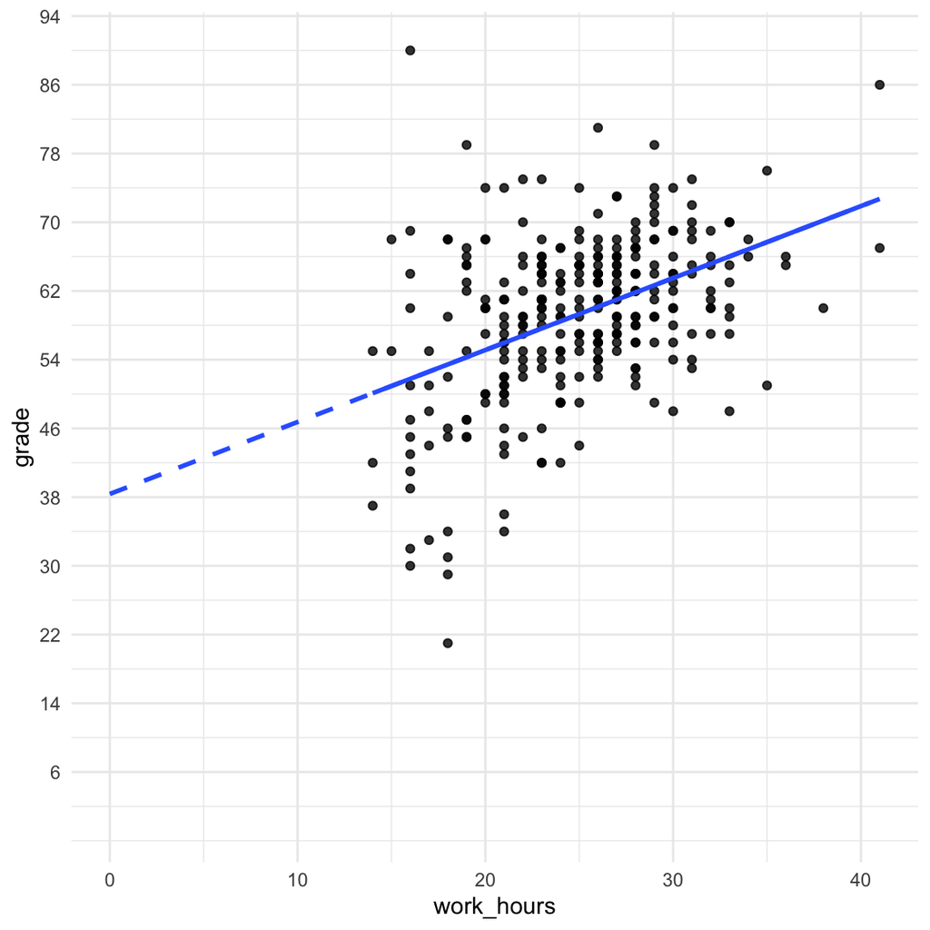

## Using coefficients

[video not shown]

We can do the same thing using the coefficients from `lm`, because we know that:

- If someone worked for 0 hours per week then our prediction would be 38.37, because this is the intercept value (the point on the line when it is at zero on the x-axis).
- For each extra hour we study the `work_hour`coefficient tells us that our `grade` will increase by 0.84.
- So, if we study for 30 hours, our prediction is $38.37 + 0.84 \times 30 = 63.57$

Using the coefficients from the model `lm(grade ~ work_hours, data = studyhabits)`:

1. Make predictions for people who study 5, 20 or 40 hours per week
2. Compare these predictions to the plot above.
3. Which of the predictions (for 5, 20 or 40 study hours) should we be most confident in? Why is this?

You should get something like: 42.6, 55.1 and 71.9

Don’t worry about rounding errors… within 1 point is fine.

We should be most confident about the prediction for 20 hours because we have more data in the sample which is close to that value. Our line was estimated from data which didn’t have many people who worked 5 or 40 hours, so we don’t really know about what happens at those extremes.

## Using `augment`

Rather than making predictions by hand, we save time by using the `augment()` function.

`augment()` takes a model, and returns the dataset used to fit it, plus new columns for the model predictions and residuals.

[video not shown]

Here’s how it works: If we run a regression, we should save the fitted model with a named variable:

```r
first.model <- lm(grade ~ work_hours, data = studyhabits)
```

If we feed this model to the `augment` function, we see a copy of the `studyhabits` data, with added columns for the model predictions (and some other things).

`augment()` is in the `broom` package so we have to load that first.

```r
library(broom)
```

```r
augment(first.model) %>% glimpse
```

```
Rows: 300
Columns: 9
$ grade      <dbl> 65, 57, 45, 70, 55, 50, 57, 69, 62, 63, 75, 67, 62, 63, 45, 64, 57, 68, 66, 21, 62, 64, 61, 52, 61…
$ work_hours <dbl> 26, 26, 16, 33, 25, 20, 32, 31, 22, 33, 22, 28, 29, 26, 18, 26, 31, 28, 23, 18, 28, 27, 23, 26, 29…
$ .fitted    <dbl> 60.15051, 60.15051, 51.77323, 66.01460, 59.31278, 55.12414, 65.17687, 64.33915, 56.79960, 66.01460…
$ .se.fit    <dbl> 0.5132544, 0.5132544, 1.0361769, 0.9700008, 0.5003213, 0.7060814, 0.8839487, 0.8017151, 0.5800900,…
$ .resid     <dbl> 4.8494933, -3.1505067, -6.7732287, 3.9853988, -4.3127789, -5.1241399, -8.1768734, 4.6608544, 5.200…
$ .hat       <dbl> 0.003510245, 0.003510245, 0.014306713, 0.012537653, 0.003335569, 0.006643265, 0.010411808, 0.00856…
$ .sigma     <dbl> 8.672905, 8.675552, 8.668451, 8.674364, 8.673864, 8.672355, 8.664367, 8.673233, 8.672213, 8.675699…
$ .cooksd    <dbl> 5.538940e-04, 2.337732e-04, 4.500801e-03, 1.360695e-03, 4.161295e-04, 1.177755e-03, 4.736241e-03, …
$ .std.resid <dbl> 0.56078448, -0.36431749, -0.78751869, 0.46296434, -0.49867632, -0.59347768, -0.94884671, 0.5403428…
```

**Explanation of the output**: The `augment` function used in line 1 has made a prediction for each row and added it to the original dataset used to fit the model. Alongside the `.fitted` value, and the `.resid` (residual) there are some other columns we can ignore for now.

Try using `augment` to make predictions from one of the regression models you have already run.

Remember, you will need to save the `lm` result to a new variable before you can use the model with these functions.

### For new samples

Often we don’t want a prediction for each row in the *original* dataset. Rather, we want predictions for specific values of the predictor variable.

To do this, we can use the `newdata` argument to `augment`.

First, we create a new single-row dataframe which contains the new predictor values we want a prediction for:

```r
newsamples <- tibble(work_hours=30)
newsamples
```

```
# A tibble: 1 x 1
  work_hours
       <dbl>
1         30
```

**Explanation of the code** The `tibble` command makes a new dataframe for us (a tibble is a special kind of dataframe). By writing `work_hours=30` we have made a single-row dataframe with a single column called `work_hours`. We saved this under the name `newsamples`.

We can use this new dataframe with the `augment` function:

```r
augment(first.model, newdata=newsamples)
```

```
# A tibble: 1 x 3
  work_hours .fitted .se.fit
       <dbl>   <dbl>   <dbl>
1         30    63.5   0.725
```

**Explanation of the output**: We have a new data frame with a prediction for a new person who worked 30 hours.

Create a new single-row dataframe to make a prediction (using `augment`) for someone who worked 33 hours per week.

# Consolidation

This video walks through the steps covered today:

[video not shown]

- Run a regression model to predict `grade` using different columns in the `studyhabits` data.
- Once you have run a model, describe in words what each of the coefficients mean (write this down)
- Talk your explanation through with a TARA or member of staff to check your understanding

# Joining data

> In the activities above we saw that to run a regression we need at least 2 columns:
1. the *outcome variable* and
2. the *predictor variable(s)*.

Previously, you recoded and created a **summary variable** for one of the 3 chosen questionnaires. This provides the *predictor*.

To predict the MCQ score (our *outcome* measure) we would need to **combine two sources of data**.

## Combining two datasets

[video not shown]

Imagine we have two datasets like this, one containing identifying information:

```
# A tibble: 3 x 2
  Identifier Name
  <chr>      <chr>
1 123ABC     Ben
2 456DEF     Helen
3 678FGH     Esther
```

And a second dataset containing sensitive questionnaire data:

```
# A tibble: 3 x 2
  Identifier `Worst ever record purchase`
  <chr>      <chr>
1 123ABC     Europe, the final countdown
2 456DEF     Spice Girls Wannabe
3 678FGH     One Direction - Night changes
```

> Note that the `Identifier` column is common to both datasets.

We can use a new `tidyverse` function which joins these two datasets into a combined table:

```r
left_join(personal_data, research_data, by="Identifier")
```

```
# A tibble: 3 x 3
  Identifier Name   `Worst ever record purchase`
  <chr>      <chr>  <chr>
1 123ABC     Ben    Europe, the final countdown
2 456DEF     Helen  Spice Girls Wannabe
3 678FGH     Esther One Direction - Night changes
```

#### Explanation of `left_join`

The `left_join` function takes two dataframes as input. We call the first input the ‘left hand side’, and the second input the ‘right hand side’.

Both left and right sides have to **share at least one column**. In this case it’s called `Identifier`.

When values in `Identifier` match in the left and right hand side then `left_join` copies the extra columns *from the right hand side into the left hand side*.

It returns the combined dataframe.

Any extra rows in the right hand side which don’t match the left hand side are dropped. This might happen if we have research data for people we don’t have personal data for. There are [other functions like `full_join`](https://dplyr.tidyverse.org/reference/join.html#join-types) which do this a bit differently, but we don’t need them for now.

- Have a look at the `heroes_meta` and `heroes_personal` datasets, in `psydata`.
- Adapt the code for `left_join()` shown above to combine these datasets.
- Pipe the result of `left_join()` to `count()` to check how many rows are in the final dataset
- Does it matter which order you join the datasets in? Can you explain the number of rows in the resulting dataset?
- Save the combined dataset into a new csv file using `write_csv()`. Check you can find this in the RStudio files pane, and download a copy to be sure.

Do the join:

```r
left_join(heroes_meta, heroes_personal)
```

```
                  name         publisher gender     eye_color              race height weight
1              Giganta         DC Comics Female         green                 -   62.5    630
2        Black Goliath     Marvel Comics   <NA>          <NA>              <NA>     NA     NA
3           Spider-Man     Marvel Comics      -           red             Human  178.0     77
4           Spider-Man     Marvel Comics   Male         brown             Human  157.0     56
5           Spider-Man     Marvel Comics   Male         hazel             Human  178.0     74
6       Superboy-Prime         DC Comics   Male          blue        Kryptonian  180.0     77
7        Lady Bullseye     Marvel Comics Female             -                 -     NA     NA
8         Black Canary         DC Comics Female          blue             Human  165.0     58
9         Black Canary         DC Comics Female          blue         Metahuman  170.0     59
10     Black Lightning         DC Comics   Male         brown                 -  185.0     90
11                X-23     Marvel Comics Female         green    Mutant / Clone  155.0     50
12          Silverclaw     Marvel Comics Female         brown                 -  157.0     50
13       Hiro Nakamura      NBC - Heroes   Male             -                 -     NA     NA
14       Beta Ray Bill     Marvel Comics   <NA>          <NA>              <NA>     NA     NA
```

[output cut: 129 more lines]

Count the rows:

```r
left_join(heroes_meta, heroes_personal) %>% count()
```

```
    n
1 689
```

```r
left_join(heroes_personal, heroes_meta) %>% count()
```

```
    n
1 691
```

We get slightly different numbers depending on which order we join the data in.

This is because `left_join` only keeps rows in the right hand dataset IF they have a match in the left hand side.

If the number of rows in the left and right hand sides differ, you can get a different result.

Other functions like `inner_join` and `full_join` take different approaches. Type `?dplyr::inner_join` for an explanation.

This would export a csv file to the same location as your `rmd` file:

```r
left_join(heroes_meta, heroes_personal) %>% rio::export('combined.csv')
```

# Extra bits

## Making a density plot

[video not shown]